# Act 5.3.2 Seaborn

## Juan Manuel González Ascencio - A00572003.

```python
import pandas as pd
import seaborn as sns
import matplotlib.pyplot as plt
```

Cargamos el archivo

```python
df = pd.read_csv("HRDataset_v14.csv")
df.head()
```

|  | Employee_Name | EmpID | MarriedID | MaritalStatusID | GenderID | EmpStatusID | DeptID | PerfScoreID | FromDiversityJobFairID | Salary | ... | ManagerName | ManagerID | RecruitmentSource | PerformanceScore | EngagementSurvey | EmpSatisfaction | SpecialProjectsCount | LastPerformanceReview_Date | DaysLateLast30 | Absences |
| --- | --- | --- | --- | --- | --- | --- | --- | --- | --- | --- | --- | --- | --- | --- | --- | --- | --- | --- | --- | --- | --- |
| 0 | Adinolfi, Wilson K | 10026 | 0 | 0 | 1 | 1 | 5 | 4 | 0 | 62506 | ... | Michael Albert | 22.0 | LinkedIn | Exceeds | 4.60 | 5 | 0 | 1/17/2019 | 0 | 1 |
| 1 | Ait Sidi, Karthikeyan | 10084 | 1 | 1 | 1 | 5 | 3 | 3 | 0 | 104437 | ... | Simon Roup | 4.0 | Indeed | Fully Meets | 4.96 | 3 | 6 | 2/24/2016 | 0 | 17 |
| 2 | Akinkuolie, Sarah | 10196 | 1 | 1 | 0 | 5 | 5 | 3 | 0 | 64955 | ... | Kissy Sullivan | 20.0 | LinkedIn | Fully Meets | 3.02 | 3 | 0 | 5/15/2012 | 0 | 3 |
| 3 | Alagbe,Trina | 10088 | 1 | 1 | 0 | 1 | 5 | 3 | 0 | 64991 | ... | Elijiah Gray | 16.0 | Indeed | Fully Meets | 4.84 | 5 | 0 | 1/3/2019 | 0 | 15 |
| 4 | Anderson, Carol | 10069 | 0 | 2 | 0 | 5 | 5 | 3 | 0 | 50825 | ... | Webster Butler | 39.0 | Google Search | Fully Meets | 5.00 | 4 | 0 | 2/1/2016 | 0 | 2 |

5 rows × 36 columns

Estadística descriptiva básica

```python
# Estadísticas descriptivas
df.describe()
```

|  | EmpID | MarriedID | MaritalStatusID | GenderID | EmpStatusID | DeptID | PerfScoreID | FromDiversityJobFairID | Salary | Termd | PositionID | Zip | ManagerID | EngagementSurvey | EmpSatisfaction | SpecialProjectsCount | DaysLateLast30 | Absences |
| --- | --- | --- | --- | --- | --- | --- | --- | --- | --- | --- | --- | --- | --- | --- | --- | --- | --- | --- |
| count | 311.000000 | 311.000000 | 311.000000 | 311.000000 | 311.000000 | 311.000000 | 311.000000 | 311.000000 | 311.000000 | 311.000000 | 311.000000 | 311.000000 | 303.000000 | 311.000000 | 311.000000 | 311.000000 | 311.000000 | 311.000000 |
| mean | 10156.000000 | 0.398714 | 0.810289 | 0.434084 | 2.392283 | 4.610932 | 2.977492 | 0.093248 | 69020.684887 | 0.334405 | 16.845659 | 6555.482315 | 14.570957 | 4.110000 | 3.890675 | 1.218650 | 0.414791 | 10.237942 |
| std | 89.922189 | 0.490423 | 0.943239 | 0.496435 | 1.794383 | 1.083487 | 0.587072 | 0.291248 | 25156.636930 | 0.472542 | 6.223419 | 16908.396884 | 8.078306 | 0.789938 | 0.909241 | 2.349421 | 1.294519 | 5.852596 |
| min | 10001.000000 | 0.000000 | 0.000000 | 0.000000 | 1.000000 | 1.000000 | 1.000000 | 0.000000 | 45046.000000 | 0.000000 | 1.000000 | 1013.000000 | 1.000000 | 1.120000 | 1.000000 | 0.000000 | 0.000000 | 1.000000 |
| 25% | 10078.500000 | 0.000000 | 0.000000 | 0.000000 | 1.000000 | 5.000000 | 3.000000 | 0.000000 | 55501.500000 | 0.000000 | 18.000000 | 1901.500000 | 10.000000 | 3.690000 | 3.000000 | 0.000000 | 0.000000 | 5.000000 |
| 50% | 10156.000000 | 0.000000 | 1.000000 | 0.000000 | 1.000000 | 5.000000 | 3.000000 | 0.000000 | 62810.000000 | 0.000000 | 19.000000 | 2132.000000 | 15.000000 | 4.280000 | 4.000000 | 0.000000 | 0.000000 | 10.000000 |
| 75% | 10233.500000 | 1.000000 | 1.000000 | 1.000000 | 5.000000 | 5.000000 | 3.000000 | 0.000000 | 72036.000000 | 1.000000 | 20.000000 | 2355.000000 | 19.000000 | 4.700000 | 5.000000 | 0.000000 | 0.000000 | 15.000000 |
| max | 10311.000000 | 1.000000 | 4.000000 | 1.000000 | 5.000000 | 6.000000 | 4.000000 | 1.000000 | 250000.000000 | 1.000000 | 30.000000 | 98052.000000 | 39.000000 | 5.000000 | 5.000000 | 8.000000 | 6.000000 | 20.000000 |

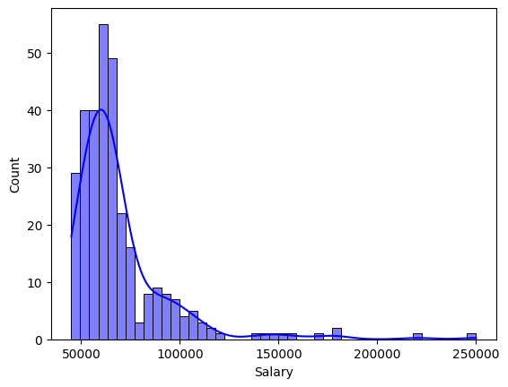

```python
#Histograma de salarios
sns.histplot(df['Salary'], kde=True, bins=45, color='blue')
```

Como podemos ver en el histograma, los salarios mas comunes se encuentran entre 50000 y los 75000 aproximadamente

La serie de tiempo (lineplot) correspondiente a la fecha de contratación (DateofHire) con el salario y desagrega por Sex. Responde: ¿en que año se contrataron más mujeres?

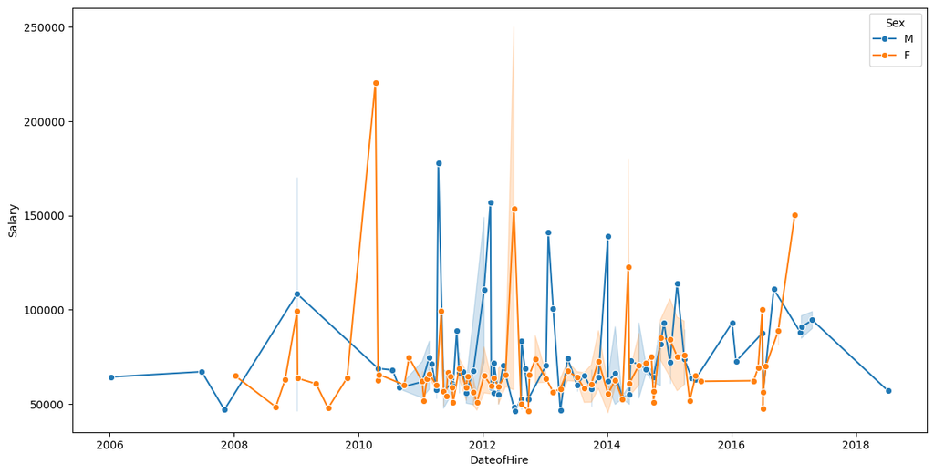

```python
#Line Plot de Date of Hire con salario desagregado por sex
df['DateofHire'] = pd.to_datetime(df['DateofHire'])

# Ordenar el DataFrame por 'DateofHire' para un mejor gráfico de líneas
df = df.sort_values('DateofHire')

# Crear el gráfico de líneas
plt.figure(figsize=(14, 7))
sns.lineplot(data=df, x='DateofHire', y='Salary', hue='Sex', marker='o')
```

Serie de tiempo (con barras) para visualizar la cantidad de contrataciones por año desagregando por sexo. Considera las dimensiones de la figura para que se aprecie adecuadamente. Agrega título y etiquetas a los ejes.

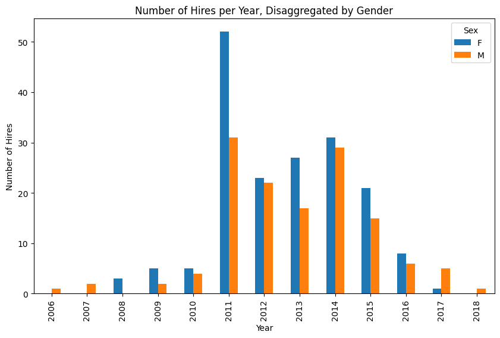

```python
# Extract the year from the DateofHire column
df['Year'] = df['DateofHire'].dt.year

# Group the data by Year and Gender and count the number of hires
hire_counts = df.groupby(['Year', 'Sex']).size().unstack()

# Create the bar plot
hire_counts.plot(kind='bar', figsize=(10, 6))

# Set the title and labels
plt.title('Number of Hires per Year, Disaggregated by Gender')
plt.xlabel('Year')
plt.ylabel('Number of Hires')

# Show the plot
plt.show()
```

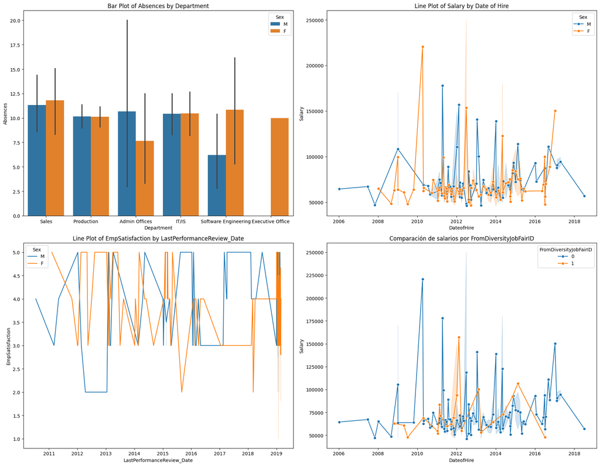

```python
# Crear la figura con 2 filas y 2 columnas para los subgráficos
fig = plt.figure(figsize=(18, 14))

# Primer subgráfico: Diagrama de barras de absences por departamento
ax1 = fig.add_subplot(2, 2, 1)
sns.barplot(data=df, x='Department', y='Absences', hue='Sex', ax=ax1)
ax1.set_title('Bar Plot of Absences by Department')

# Segundo subgráfico: Line Plot de Date of Hire con salario desagregado por sex
ax2 = fig.add_subplot(2, 2, 2)
sns.lineplot(data=df, x='DateofHire', y='Salary', hue='Sex', marker='o', ax=ax2)
ax2.set_title('Line Plot of Salary by Date of Hire')

# Tercer subgráfico: LastPerformanceReview_Date y EmpSatisfaction
ax3 = fig.add_subplot(2, 2, 3)
df['LastPerformanceReview_Date'] = pd.to_datetime(df['LastPerformanceReview_Date'])
sns.lineplot(data=df, x='LastPerformanceReview_Date', y='EmpSatisfaction', hue='Sex', ax=ax3)
ax3.set_title('Line Plot of EmpSatisfaction by LastPerformanceReview_Date')

# Cuarto subgráfico: FromDiversityJobFairID y Salary
ax4 = fig.add_subplot(2, 2, 4)
sns.lineplot(data=df, x='DateofHire', y='Salary', hue='FromDiversityJobFairID', marker='o', ax=ax4)
ax4.set_title('Comparación de salarios por FromDiversityJobFairID')

plt.tight_layout()  # Ajusta el espaciado entre los subgráficos
plt.show()
```

### (10 pts) Usando el contexto poster, genera un gráfico de tipo JointPlot donde muestres su recta de regresión. Responde: ¿cómo se interpreta el gráfico?

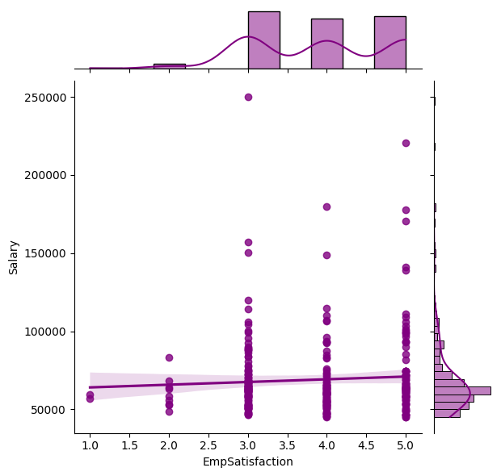

```python
#Usando el contexto poster, genera un gráfico de tipo JointPlot donde muestres su recta de regresión.

sns.jointplot(data=df, x='EmpSatisfaction', y='Salary', kind='reg', color='purple')
plt.show()
```

Sin embargo, mientras aumenta la satisfacción tambien tiende a aumentar el sueldo, lo cual tiene sentido.

Podemos ver que el sueldo mas alto lo tiene una persona con satisfacción de 3, lo cual puede ser debido a la cantidad de horas que trabaja o algo por el estilo.

### Genera el mapa de calor con los coeficientes de correlación y muestra el diagrama de dispersión de puntos de aquel par de variables con coeficiente aproximadamente igual a 0.51 junto con su rugplot.

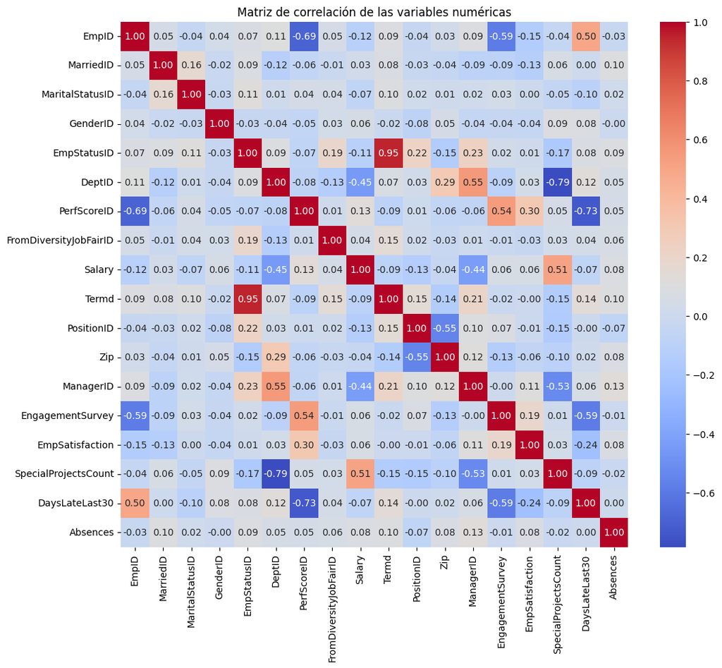

```python
#Genera el mapa de calor con los coeficientes de correlación y muestra el diagrama de dispersión de puntos de aquel par de variables con coeficiente aproximadamente igual a 0.51 junto con su rugplot.

# quirar las columnas no numéricas
dfNum = df.select_dtypes(include=['int64', 'float64'])

# Calcular la matriz de correlación
correlation_matrix = dfNum.corr()

# Crear el mapa de calor
plt.figure(figsize=(12, 10))
sns.heatmap(correlation_matrix, annot=True, cmap='coolwarm', fmt='.2f')
plt.title('Matriz de correlación de las variables numéricas')
plt.show()
```

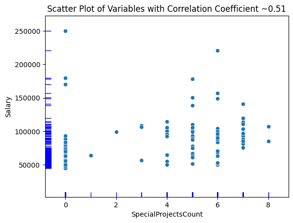

```python
# Seleccionamos las variables con una correlación de 0.51
variable1 = 'SpecialProjectsCount'
variable2 = 'Salary'

# Creamos la scatterplot
sns.scatterplot(data=df, x=variable1, y=variable2)

# Añadimos el rugplot para la prumera variable
sns.rugplot(data=df, x=variable1, y=variable2, color='blue')

# Ponemos los titulos y lables
plt.title('Scatter Plot of Variables with Correlation Coefficient ~0.51')
plt.xlabel(variable1)
plt.ylabel(variable2)


plt.show()
```

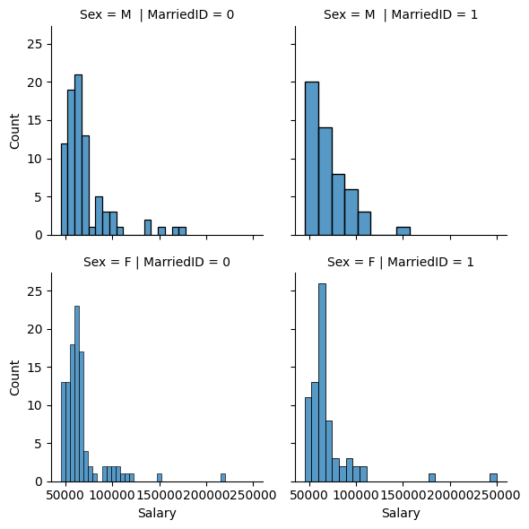

```python
#Realiza una comparativa de salarios a través de diferentes grupos mediante un Faceted histogram. Responde cuál es el género y estado civil con mayor prevalencia de remuneración baja.

# Create a FacetGrid with 'Gender' and 'MaritalStatus' as the facets
g = sns.FacetGrid(df, row='Sex', col='MarriedID')

# Plot the histogram of 'Salary' for each facet
g.map(sns.histplot, 'Salary')

# Show the plot
plt.show()
```